# PSYCH 260

2020-08-25 14:12:50

## Prelude (9:01)

[video not shown]

## Today’s topics

- History of neuroscience
- Levels of analysis
- Methods to the madness

## Warm-up

## Neuroscience is harder than physics because…

- A. The brain has more parts than any other physical entity we know about.
- B. Physicists have largely ignored biology.
- C. Nervous systems are influenced by multiple factors we can’t (yet) measure effectively.
- D. Physicists only study “toy” problems.

## Neuroscience is harder than physics because…

- A. The brain has more parts than any other physical entity we know about.
- B. Physicists have largely ignored biology.
- C. Nervous systems are influenced by multiple factors we can’t (yet) measure effectively.
- D. Physicists only study “toy” problems.

## Systems have all of the following components EXCEPT:

- A. Boundaries
- B. Components
- C. Interactions among components
- D. Inputs and outputs
- E. Readily predictable behavior

## Systems have all of the following components EXCEPT:

- A. Boundaries
- B. Components
- C. Interactions among components
- D. Inputs and outputs
- E. Readily predictable behavior

## *“If understanding everything we need to know about the brain is a mile, how far have we walked?”*

J. Lichtman, https://www.youtube.com/watch?v=nvXuq9jRWKE&feature=youtu.be

## History of neuroscience

## Why study history?

- What can *observation* tell us about brain and behavior?
- Vital role of *tools/methods/techniques* in discovery
- *“If I have seen further, it is by standing on the shoulders of giants.”* – Isaac Newton, 1676

[video not shown]

## What did early humans know about the mind and brain?

- Mental functions controlled by organs in the head, i.e., the brain
- Mental functions can be influenced by substances we consume
- Head injury can impair behavior and thinking
- Something flows from brain to body via nerves

## Why didn’t they know more?

## Why didn’t they know more?

- A. Limited technology.
- B. Limited cultural support for systematic observation & description. = SCIENCE
- C. Lack of ability to use knowledge even if it were acquired.

## The body as machine (René Descartes – mid 1600’s)

[figure not shown]

## Descartes’ ‘reflexes’

- Reflexes “reflect” events in the world
- Not the same as voluntary functions

## Descartes’ reflexes

[figure not shown]

## Descartes’ ‘dualism’

- Reflexes and animal “minds” are physical, machine-like
- Human mind is not
  - “Dual” influences on behavior
  - Physical + spiritual
- Soul controls body via *pineal gland*
  - Causes muscles to “inflate”

## Pineal gland

[figure not shown]

## Do you agree with Descartes?

- A. **Yes**, human minds are fundamentally different from animal minds. The human mind is influenced by both physical and extraphysical processes.
- B. **No**, human minds are similar to animal minds. The human mind arises solely from physical processes.

## How would you test Descartes idea about the role of the pineal gland?

## The lessons from history

- Neuroscience shaped by new methods, tools
- Neuroscience shaped by [great debates](http://www.columbia.edu/cu/psychology/courses/1010/mangels/neugiro/history/history.html)
  - Mind == brain debate
  - Are functions local or distributed?
  - Nature of neural communication
- Forms at multiple levels of analysis contribute to function

## Levels of analysis

## Spatial resolution

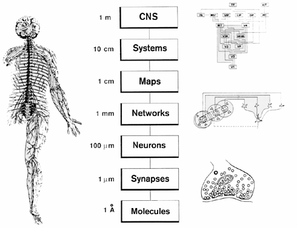

## Spatial and Temporal Resolution

[figure not shown]

[Sejnowski 2014](http://doi.org/10.1038/nn.3839)

## Spatial Resolution in Detail

- Within an individual
  - molecular
    - genetic
    - receptor
  - chemical
    - neurotransmitter/hormonal
  - cellular
    - neuronal firing

## Spatial Resolution in Detail

- Internal to individuals
  - network
    - lateral inhibition
  - area
    - V1 varies by ~2x
  - region
    - Wiring/connectivity differences
  - system

## Spatial Resolution in Detail

- External to individuals
  - Social
    - Friends, family, teachers, others
  - Non-social
    - Neighborhood, school, state/region, country
    - Physical environment

## Temporal Resolution in Detail

- Within one lifetime
  - Microseconds
    - detection position from acoustic stimulation
  - Milliseconds
    - action potential
  - Seconds
    - changes in EEG power
    - short-term memory

## Temporal Resolution in Detail

- Within one lifetime
  - Minutes
    - synaptic plasticity
  - Hours
    - memory consolidation
    - Hormone (melatonin, cortisol) levels
  - Days

## Temporal Resolution in Detail

- Within one lifetime
  - Weeks
  - Months
  - Years
    - education & training
    - disease processes
    - cultural change

## Temporal Resolution in Detail

- Across lifetimes
  - Centuries
    - cultural changes
  - Millenia
    - Natural & sexual selection

## Why does this matter?

- Different methods, different levels of analysis
- Challenge of linking phenomena across levels
  - How does the micro affect macro or vice versa?
- Challenge of interpretation

## Neuroscience methods

## Methods to the madness

- Tools in the neuroscientist’s toolkit
- What they tell us, and what they don’t

## Evaluating methods

- What is the question?
- What are we measuring?
  - Structure
  - Activity
- Strengths & Weaknesses
  - Cost
  - Invasiveness
  - Spatial/temporal resolution

## Spatial and Temporal Resolution

[figure not shown]

[Sejnowski 2014](http://doi.org/10.1038/nn.3839)

## Types of methods

- Structural
  - Mapping the circuitry
  - Anatomy & connectivity
- Functional (next time)
  - What does it do?
  - Physiology/Activity

## Mapping structures

- Cell/axon stains
  - *Golgi stain* – whole cells
    - [Camillo Golgi](https://en.wikipedia.org/wiki/Camillo_Golgi)
  - *Nissl stain* – cell bodies only
    - [Franz Nissl](https://en.wikipedia.org/wiki/Franz_Nissl)
  - Cellular distribution, concentration, microanatomy

## [Golgi stain](http://2e.mindsmachine.com/glossary.html#G)

[figure not shown]

## [Nissl stain](http://2e.mindsmachine.com/glossary.html#N)

[figure not shown]

## Retrograde vs. anterograde [histochemical tracers](https://en.wikipedia.org/wiki/Histochemical_tracer)

- Neuron information flow *polarized*–flows in one direction
- *Retrograde* (from *axon terminal* to *cell body*); *anterograde* (from cell body to axon terminal)
- What connects where

## Retrograde vs. anterograde tracers

[figure not shown]

## [Brainbow](http://cbs.fas.harvard.edu/science/connectome-project/brainbow)

[figure not shown]

[Lichtman, 2008](http://doi.org/10.1038/nrn2391)

## Brainbow

[figure not shown]

[Lichtman, 2008](http://doi.org/10.1038/nrn2391)

[video not shown]

## [Clarity](http://clarityresourcecenter.com/CLARITY.html)

[video not shown]

## Evaluating cellular tracing techniques

- Invasive (in humans post-mortem only)
- High spatial resolution, but poor temporal resolution
  - Why?

## Mapping structures

- Computed axial tomography (CAT), computed tomography [CT](https://en.wikipedia.org/wiki/CT_scan)
- X-ray based

## Tomography

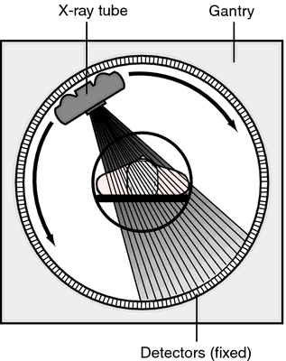

## Tomography

[figure not shown]

https://cdn.hswstatic.com/gif/cat-scan-pineapple.jpg

## CT scan of stroke

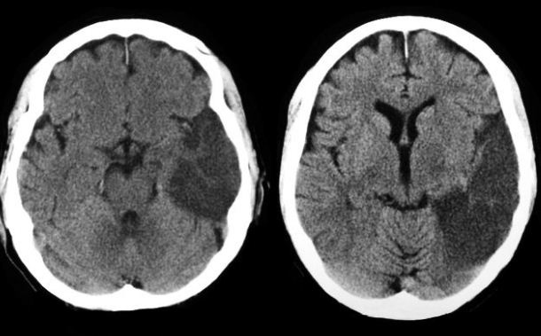

## [Magnetic Resonance Imaging (MRI)](https://en.wikipedia.org/wiki/Magnetic_resonance_imaging)

- Magnetic resonance
- Some common isotopes (e.g., H) & complex molecules have a magnetic dipole
- Axes align with strong magnetic field
- When alignment perturbed by radio frequency (RF) pulse, speed of realignment varies by tissue
- Realignment emits RF signals

## MRI

[figure not shown]

https://cdn.hswstatic.com/gif/mri-steps.jpg

## How MRI works

[video not shown]

## Structural MRI

- Reveals tissue density/type differences
- [Gray matter](https://en.wikipedia.org/wiki/Grey_matter) (neurons & dendrites & axons & glia) vs. [white matter](https://en.wikipedia.org/wiki/White_matter) (mostly axons)
- MR Spectroscopy
- Region sizes/volumes

## Structural MRI of the brain

[figure not shown]

## [Diffusion tensor imaging (DTI)](https://en.wikipedia.org/wiki/Diffusion_MRI#Diffusion_tensor_imaging)

[figure not shown]

## [Diffusion tensor imaging (DTI)](https://en.wikipedia.org/wiki/Diffusion_MRI#Diffusion_tensor_imaging)

- Type of structural MRI
- Reveals integrity/density of axon fibers
- Measure of connectivity

## [Voxel-based morphometry (VBM)](https://en.wikipedia.org/wiki/Voxel-based_morphometry)

- [Voxels (volume-based elements)](https://en.wikipedia.org/wiki/Voxel)
- Morphometry, measure (“metry”) form/morphology.
- How does brain size or thickness vary by age, disease status, etc.?

[figure not shown]

http://www.frontiersin.org/files/Articles/18691/fnhum-06-00184-HTML/image_m/fnhum-06-00184-g003.jpg

## Main points

- Spatial vs. temporal resolution
- Structural methods (parts, sizes, connectivity)

## Next time…

- *Functional* neuroscience methods
- Neuroanatomy